Alvaro Silva

Palette

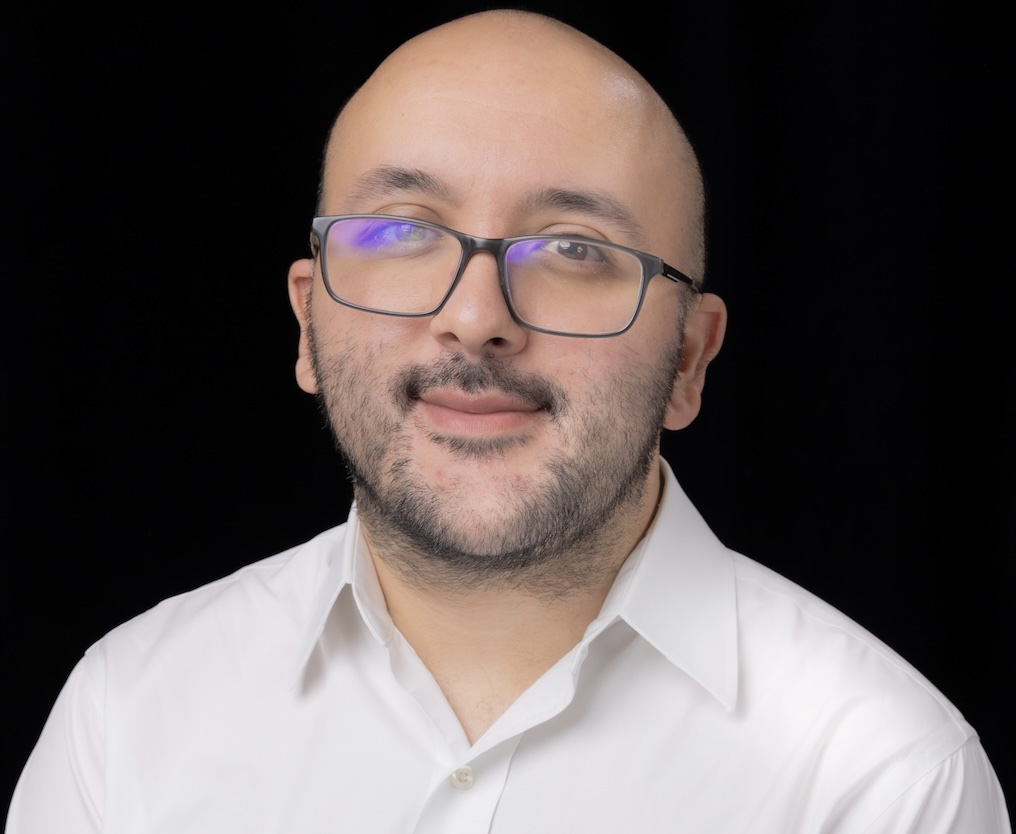

# Alvaro Silva

I am an economist at the Federal Reserve Bank of Boston. I work on international economics.

Papers CV Email: asilvub@gmail.com [Boston Fed Page](https://www.bostonfed.org/people/bank/alvaro-silva.aspx) [X](https://twitter.com/Asilvub)

The views expressed here are my own and do not necessarily represent the views of the Federal Reserve Bank of Boston or the Federal Reserve System.

Things I Learn and Forget

# Dimensional Analysis in Macroeconomics

Alvaro Silva

August 8, 2026

Summary

This note studies dimensional consistency in macroeconomic models. I use dimensional analysis to distinguish stocks from flows, period quantities from instantaneous rates, nominal values from real quantities, and physical productivity from valuation. My starting point is simple: the predictions of a model should not depend on whether an object is measured in dollars or cents, units or thousands of units, and quarters or years. I show that making the underlying normalization explicit is especially important for CES technologies and preferences, sectoral TFP aggregation, and market-clearing conditions with heterogeneous goods. Dimensional consistency does not establish that a model is economically correct. It provides a useful first check that its equations have a well-defined economic meaning.

## Why I wrote this note

I wrote this note because dimensional consistency is usually left implicit in macroeconomics. In the models I tend to read and write—multi-sector production models, open-economy models, and production networks—we routinely add sectoral quantities, report TFP levels, take logarithms, and change substitution elasticities while holding “share” parameters fixed. This convention is often harmless because the intended normalization is understood. Yet it can also make a counterfactual depend on whether output is measured in dollars, thousands of dollars, tons, or units of an index.

The issue is most relevant in quantitative work. A model can fit its baseline even when residual TFP or a CES coefficient absorbs the units chosen by the researcher. Changing an elasticity, a network weight, or sectoral composition may then change the meaning of a parameter that was meant to remain fixed. The purpose of the note is to separate this problem from harmless notational shorthand and to provide checks that can be applied directly to a macroeconomic model.

# The problem

My starting point is invariance to units. An equation should describe the same economy whether we measure output in dollars or cents, capital in units or thousands of units, and time in quarters or years. Numerical values will change, but the allocation and its economic meaning should not.

Let $X$ denote a generic economic object and let $\operatorname{dim}\!\left(X\right)$ denote its dimension, as distinct from its numerical value in a particular system of units. I reserve square brackets for ordered index sets such as $[N]=\{1,\ldots,N\}$, where $N$ is the number of elements in the set. A dimension is also distinct from a selected unit: output may have dimension goods per unit of time and be measured in tons per year. The symbols used below include time $\mathsf{T}$, a monetary numeraire $\mathsf{N}$, a physical good $\mathsf{G}$, and labor-hours $\mathsf{H}$. The dimensionless class is denoted by $\mathsf{1}$. Thus, if $Y$ denotes physical output flow and $K$ denotes the capital stock,
$$\operatorname{dim}\!\left(Y\right)=\frac{\mathsf{G}}{\mathsf{T}},
\qquad
\operatorname{dim}\!\left(K\right)=\mathsf{G}.$$
Dimensions are equivalence classes under changes in measurement units. Changing from dollars to cents changes the numerical value of a nominal object but not its economic content. A well-formed equation transforms coherently under any such change.

This perspective separates two questions that economic notation often conflates. First, is an equation meaningful under arbitrary unit changes? Second, is it a correct description of the economy? Dimensional consistency answers only the first question. For example, if $C_t$ denotes consumption and $Y_t$ denotes output at date $t$, then $C_t=2Y_t$ may be dimensionally valid and economically false.

Time subscripts also require care. A unit of the consumption good dated $t$ and one dated $t+1$ are different commodities economically, but they normally share the same physical dimension. Intertemporal prices and returns may therefore be dimensionless in the physical sense while retaining economically essential date labels.

# Rules for dimensional analysis

I use the following five rules throughout the note. Together, they provide almost all of the required bookkeeping. In these rules, $X$ and $Y$ denote arbitrary scalar objects, $a$ is a scalar exponent, $t$ denotes continuous time, $F$ is a differentiable mapping, and $F_X:=\partial F/\partial X$ is its derivative with respect to $X$. A dot denotes a derivative with respect to time.

**Principle 1** (Equality and addition). *If $X=Y$, then $\operatorname{dim}\!\left(X\right)=\operatorname{dim}\!\left(Y\right)$. If $X+Y$ is defined, then $\operatorname{dim}\!\left(X\right)=\operatorname{dim}\!\left(Y\right)$. In particular, because the number $1$ is dimensionless, $1-a$ is meaningful only if $a$ is dimensionless.*

**Principle 2** (Products, powers, and ratios). Dimensions multiply and divide:
$$\operatorname{dim}\!\left(XY\right)=\operatorname{dim}\!\left(X\right)\operatorname{dim}\!\left(Y\right),
\qquad
\operatorname{dim}\!\left(X/Y\right)=\frac{\operatorname{dim}\!\left(X\right)}{\operatorname{dim}\!\left(Y\right)},
\qquad
\operatorname{dim}\!\left(X^a\right)=\operatorname{dim}\!\left(X\right)^{a},$$
where the exponent $a$ must itself be dimensionless. A ratio is dimensionless only when numerator and denominator have the same dimension.

**Principle 3** (Derivatives and integrals). If $Y=F(X)$, then
$$\operatorname{dim}\!\left(F_X\right)=\frac{\operatorname{dim}\!\left(Y\right)}{\operatorname{dim}\!\left(X\right)}.$$
Likewise, $\operatorname{dim}\!\left(\dot X\right)=\operatorname{dim}\!\left(X\right)/\mathsf{T}$ and $\operatorname{dim}\!\left(\int X(t)\mathop{}\!\mathrm dt\right)=\operatorname{dim}\!\left(X\right)\mathsf{T}$.

**Principle 4** (Nonlinear functions). *The arguments of $\log(\cdot)$, $\exp(\cdot)$, trigonometric functions, and power-series expressions must be dimensionless. Thus $\log X$ is shorthand for $\log(X/X^{\circ})$, where $X^{\circ}$ has the same dimension as $X$.*

**Principle 5** (Parameters). *A parameter is not dimensionless by default. Its dimension is determined by the equation in which it appears. A parameter may therefore change numerically when the units of an observable change, even when the underlying economy is unchanged.*

The corresponding operational test is a rescaling test. Replace each primitive quantity by the same economic object expressed in new units, transform every dimensional parameter accordingly, and ask whether the model implies the same allocation and prices after converting back. Failure of this test signals either an inconsistent equation or a hidden normalization.

# Proper normalization

The natural solution is to express dimensional objects relative to reference levels. For any dimensional object $X$, choose an explicit reference quantity $X^{\circ}>0$ with $\operatorname{dim}\!\left(X^{\circ}\right)=\operatorname{dim}\!\left(X\right)$, and work with
$$\frac{X}{X^{\circ}}.$$
This ratio is dimensionless and invariant to a common change in the units used for $X$ and $X^{\circ}$. The reference level may be a benchmark allocation, a steady state, or a fixed unit convention. It need not be an equilibrium object, but it must be stated.

For a production function, let $Y$ denote output, $K$ capital, and $L$ labor services. Let $Y^{\circ}$, $K^{\circ}$, and $L^{\circ}$ be positive reference levels with the same dimensions as their corresponding variables, let $\theta$ denote a dimensionless structural parameter, and let $\mathcal F$ be a dimensionless production mapping. A useful normalized representation is
$$\frac{Y}{Y^{\circ}}
=
\mathcal F\!\left(
\frac{K}{K^{\circ}},
\frac{L}{L^{\circ}};
\theta
\right),
\tag{1}$$
The dimensional scales are carried by $Y^{\circ}$, $K^{\circ}$, and $L^{\circ}$. This representation distinguishes a change in technology from a change in physical units.

Normalization does not make all parameters structural or comparable across models. It only makes the unit convention explicit. Two normalizations describe the same technology when their parameters are transformed so that the underlying mapping from physical inputs to physical output is unchanged.

It is useful to distinguish three cases. First, an equation may be explicitly normalized, in which case every nonlinear operation is applied to dimensionless objects. Second, it may be dimensionally correct only because one or more coefficients carry units; those coefficients must change when the measurement units change. Third, it may simply add incommensurable objects. Only the third case is a formal error. The second is often legitimate, but it becomes dangerous when a dimensional coefficient is interpreted as a structural share and held fixed in a counterfactual.

# Worked examples

I now apply these rules to familiar macroeconomic expressions. I start with time, then turn to production and aggregation, and finally consider prices, preferences, and elasticities.

## Stocks, flows, and depreciation

I start with the distinction between a stock and a flow. Let $t$ index discrete periods, let $K_t$ be the capital stock measured at the boundary between periods, let $I_t$ be gross investment accumulated during period $t$, let $\Delta$ denote the period length, and let $\delta_{\Delta}$ be the fraction of capital lost over one period. Then
$$K_{t+1}=(1-\delta_{\Delta})K_t+I_t
\tag{2}$$
is dimensionally consistent with
$$\operatorname{dim}\!\left(K_t\right)=\operatorname{dim}\!\left(I_t\right)=\mathsf{G},
\qquad
\operatorname{dim}\!\left(\delta_{\Delta}\right)=\mathsf{1}.$$
The subscript $\Delta$ emphasizes the period convention. The depreciation fraction cannot have units $1/\mathsf{T}$, because then $1-\delta_{\Delta}$ would be undefined. For example, quarterly depreciation of 10 percent means $\delta_{\Delta}=0.10$ for a quarter. It is not an instantaneous rate of $0.10$ per unit of time.

In continuous time, let $K(t)$ be the capital stock at instant $t$, let $I(t)$ be the instantaneous investment flow, and let $\delta_c$ be the instantaneous depreciation rate. Then
$$\dot K(t)=I(t)-\delta_c K(t).
\tag{3}$$
Now
$$\operatorname{dim}\!\left(\dot K\right)=\operatorname{dim}\!\left(I\right)=\frac{\mathsf{G}}{\mathsf{T}},
\qquad
\operatorname{dim}\!\left(\delta_c\right)=\frac{\mathsf{1}}{\mathsf{T}}.$$
Here and below, I suppress time arguments inside the dimension operator when no confusion can result. Under exponential depreciation the exact bridge between the two conventions is
$$1-\delta_{\Delta}=\exp(-\delta_c\Delta).
\tag{4}$$
The exponent is dimensionless. For a short period, $\delta_{\Delta}=\delta_c\Delta+o(\Delta)$, where $o(\Delta)$ denotes a remainder that becomes negligible relative to $\Delta$ as $\Delta\to0$.

The same distinction applies to every discrete macro equation. Consumption, output, and investment may denote amounts accumulated during a period or rates per unit of time. Either convention is admissible, but the convention must be used consistently on both sides of every equation.

## Gross returns, net rates, and asset prices

The same time distinction applies to interest rates. Let $A_t$ denote a position in a one-period real asset, measured in units of the date-$t$ good, and let $R_{t+1}$ denote its gross real return between dates $t$ and $t+1$. The asset exchanges $A_t$ units of the good at date $t$ for $R_{t+1}A_t$ units at date $t+1$. Since the two payoffs share the same physical dimension,
$$\operatorname{dim}\!\left(R_{t+1}\right)=\mathsf{1}.$$
More explicitly, $R_{t+1}$ is an intertemporal conversion rate with the economic label $\mathsf{G}_{t+1}/\mathsf{G}_t$, where $\mathsf{G}_t$ denotes one unit of the physical good delivered at date $t$; dimensional analysis suppresses dates and reduces this to $\mathsf{G}/\mathsf{G}=\mathsf{1}$. The one-period net rate $r_{t+1}=R_{t+1}-1$ is also dimensionless.

The asset price is a different object. Let $Q_t^B$ be the price of a nominal zero-coupon bond, quoted in units of numeraire at $t$ per unit of numeraire paid at $t+1$, and let $R_{t+1}^N$ be its gross nominal return. Then
$$Q_t^B:\frac{\mathsf{N}_t}{\mathsf{N}_{t+1}},
\qquad
R_{t+1}^N=\frac{1}{Q_t^B}.$$
Here $\mathsf{N}_t$ denotes one unit of numeraire delivered at date $t$. Both are intertemporal conversion factors; after suppressing date labels, both are dimensionless ratios. This does not imply that the bond position itself is dimensionless: a nominal position has dimension $\mathsf{N}$.

In continuous time, let $A(t)$ denote the value of the real asset position and let $r_c(t)$ denote its instantaneous continuously compounded return. If
$$\dot A(t)=r_c(t)A(t),$$
then $\operatorname{dim}\!\left(r_c\right)=\mathsf{1}/\mathsf{T}$. Let $R_{t,t+\Delta}$ denote the gross return over the interval from $t$ to $t+\Delta$. Using $s$ as the dummy time variable in the integral,
$$R_{t,t+\Delta}
=\exp\!\left(\int_t^{t+\Delta}r_c(s)\mathop{}\!\mathrm ds\right)$$
is dimensionless. Thus a gross return over a stated interval is a ratio; an instantaneous interest rate is a rate per unit of time.

This distinction governs legitimate subtractions. In discrete time one may form $R_{t+1}-1-\delta_{\Delta}$. In continuous time one may form $r_c-\delta_c$. Mixing $r_c$ with $\delta_{\Delta}$ is not meaningful without converting them to the same time convention.

## Production functions, TFP, and marginal products

I next consider production. Let $Y$ be output flow, $K$ the capital stock, $L$ the flow of labor services, and $\mathsf{G}_K$ the physical dimension of the capital good:
$$\operatorname{dim}\!\left(Y\right)=\frac{\mathsf{G}}{\mathsf{T}},
\qquad
\operatorname{dim}\!\left(K\right)=\mathsf{G}_K,
\qquad
\operatorname{dim}\!\left(L\right)=\frac{\mathsf{H}}{\mathsf{T}}.$$
Let $F(K,L)$ be a production aggregator and let $Z$ denote total factor productivity (TFP). For the general technology
$$Y=Z F(K,L),
\tag{5}$$
the dimension of measured TFP is the residual
$$\operatorname{dim}\!\left(Z\right)=\frac{\operatorname{dim}\!\left(Y\right)}{\operatorname{dim}\!\left(F(K,L)\right)}.$$
There is no presumption that $Z$ is dimensionless. Its numerical level depends on the units of output and inputs and on the normalization of $F$. TFP levels are therefore not automatically comparable across sectors or specifications. For example, measuring the same output in thousands of units divides the numerical value of $Z$ by one thousand if the inputs and $F$ are left unchanged. The technology has not changed; only its numerical representation has.

For Cobb–Douglas production, let $\alpha\in(0,1)$ be the dimensionless capital exponent, so $1-\alpha$ is the labor exponent:
$$Y=ZK^{\alpha}L^{1-\alpha},
\qquad \alpha\in(0,1),
\tag{6}$$
the multiplication is well defined even when $K$ and $L$ have different dimensions, but TFP carries the residual units
$$\operatorname{dim}\!\left(Z\right)
=
\frac{\mathsf{G}/\mathsf{T}}
{\mathsf{G}_K^{\alpha}(\mathsf{H}/\mathsf{T})^{1-\alpha}}.$$
Let $Z^{\circ}>0$ be the reference TFP level corresponding to the reference allocation. An explicitly normalized version is
$$\frac{Y}{Y^{\circ}}
=
\frac{Z}{Z^{\circ}}
\left(\frac{K}{K^{\circ}}\right)^{\alpha}
\left(\frac{L}{L^{\circ}}\right)^{1-\alpha},
\tag{7}$$
where the reference values satisfy the level equation. Every term in Equation 7 is dimensionless.

This explains why the issue is easy to miss in Cobb–Douglas models. Its multiplicative form can absorb a change in the units of $K$, $L$, or $Y$ into the level of $Z$. The equation remains well formed, but the numerical TFP level is not an invariant object. In this sense Cobb–Douglas normally contains an *implicit* normalization; writing ratios as in Equation 7 makes it explicit.

Derivatives of the complete production mapping retain economically meaningful units:
$$\operatorname{dim}\!\left(\frac{\partial Y}{\partial K}\right)=\frac{\mathsf{G}/\mathsf{T}}{\mathsf{G}_K},
\qquad
\operatorname{dim}\!\left(\frac{\partial Y}{\partial L}\right)
=\frac{\mathsf{G}/\mathsf{T}}{\mathsf{H}/\mathsf{T}}=\frac{\mathsf{G}}{\mathsf{H}}.$$
If capital is measured in units of the output good, then $\operatorname{dim}\!\left(\partial Y/\partial K\right)=\mathsf{1}/\mathsf{T}$: the marginal product of capital is an output flow per unit of capital stock. The marginal product of labor is output per labor-hour.

## Why CES requires explicit normalization

The contrast between Cobb–Douglas and CES is useful. Let $\sigma>0$ denote the dimensionless elasticity of substitution and define the dimensionless curvature parameter $\rho:=(\sigma-1)/\sigma$. Retaining $\alpha$ as the capital distribution parameter, consider the familiar expression
$$Y
=Z\left[\alpha K^{\rho}+(1-\alpha)L^{\rho}\right]^{1/\rho},
\qquad
\rho=\frac{\sigma-1}{\sigma}.
\tag{8}$$
To see the problem, suppose $K$ and $L$ have different dimensions. The two terms inside the brackets cannot be added. Assigning units to $\alpha$ does not rescue this parameterization: the expression $1-\alpha$ itself requires $\operatorname{dim}\!\left(\alpha\right)=\mathsf{1}$.

This is the point made especially clearly by [Cantore and Levine (2012)](https://doi.org/10.1016/j.jedc.2012.05.009). Their starting observation, building on de Jong and Quade (1967) and de Jong and Kumar (1972), is that the coefficients conventionally called CES shares are generally *dimensional constants*: their numerical values depend on the units of the inputs and output. The older normalization literature develops the same lesson for production functions; see, among others, de La Grandville (1989), Klump and de La Grandville (2000), Klump and Preissler (2000), Klump and Saam (2008), and Klump, McAdam, and Willman (2012). Cantore and Levine also show that the issue extends beyond production to Dixit–Stiglitz indices in multi-sector and open-economy models.

The clean calibrated-share form is
$$\frac{Y}{Y^{\circ}}
=
\frac{Z}{Z^{\circ}}
\left[
\alpha\left(\frac{K}{K^{\circ}}\right)^{\rho}
+(1-\alpha)\left(\frac{L}{L^{\circ}}\right)^{\rho}
\right]^{1/\rho}.
\tag{9}$$
Now the inputs to the sum are dimensionless and $\alpha$ is a genuine dimensionless distribution parameter. If the reference allocation satisfies the level equation, then the CES aggregator equals one at the reference point. As $\sigma\to1$, or equivalently $\rho\to0$, equation Equation 9 converges to the normalized Cobb–Douglas form.

An alternative is to let $a_K$ and $a_L$ denote dimensional coefficients on capital and labor and write $a_KK^{\rho}+a_LL^{\rho}$, assigning dimensions to the coefficients that make the summands commensurable. These coefficients are then conversion factors, not shares, and in general it is meaningless to impose $a_K+a_L=1$. The normalized form makes the intended economic interpretation more transparent. A reference allocation is still a substantive choice: different baseline points need not generate the same comparison when the elasticity changes (Temple 2012). Normalization removes dependence on arbitrary measurement units; it does not remove every modeling choice.

## Sectoral TFP and aggregation

The same issue reappears when productivity is aggregated across sectors. Let $[N]=\{1,\ldots,N\}$, $[F]=\{1,\ldots,F\}$, and $[I]=\{1,\ldots,I\}$ be the ordered sets of domestic goods, factors, and imported goods, respectively; $n,n'$, $f$, and $i$ denote typical elements of those sets. For domestic sector $n$, let $Q_n$ be gross physical output, $Z_n$ sectoral TFP, and $F_n$ its production mapping. Let $L_{nf}$ be the quantity of factor $f$ used by sector $n$, $M_{nn'}$ the quantity of domestic input $n'$ purchased by sector $n$, and $M_{ni}$ the quantity of imported input $i$ purchased by sector $n$. Sector $n$ produces according to
$$Q_n=Z_nF_n\!\left(
\{L_{nf}\}_{f\in[F]},
\{M_{nn'}\}_{n'\in[N]},
\{M_{ni}\}_{i\in[I]}
\right).
\tag{10}$$
Because $Q_n$, the input bundle, and even the Cobb–Douglas exponents may differ across sectors, the residual $Z_n$ need not have the same dimension as $Z_{n'}$. Consider a candidate aggregate TFP level $Z$ constructed with dimensionless weights $\omega_n$ that sum to one. The expression
$$Z=\sum_{n\in[N]}\omega_n Z_n$$
is not generally defined, even if the weights sum to one. The reason is that the weights are not physical conversion factors.

This does not mean that productivity cannot be aggregated. It means that the object being aggregated must first be defined. One possibility is to aggregate normalized productivity indices. Let $Z_n^{\circ}>0$ denote sector $n$’s reference TFP level and let $\mathcal Z$ denote the resulting dimensionless aggregate:
$$\mathcal Z
=\prod_{n\in[N]}
\left(\frac{Z_n}{Z_n^{\circ}}\right)^{\omega_n},
\qquad
\sum_{n\in[N]}\omega_n=1,$$
which is dimensionless and depends on the stated reference levels. Alternatively, under the assumptions that justify it, let $\lambda_n$ denote sector $n$’s dimensionless Domar weight—its nominal gross sales divided by nominal GDP. One can then write a local growth-accounting formula such as
$$\mathop{}\!\mathrm d\log \mathcal Z
=\sum_{n\in[N]}\lambda_n\,\mathop{}\!\mathrm d\log Z_n,$$
which aggregates log changes; it does not prove that the physical TFP levels can be added.

## Prices and nominal versus real units

Prices provide one way to make heterogeneous goods commensurable. Continue to let sector $n\in[N]=\{1,\ldots,N\}$ produce physical output flow $Q_n$ of good $n$, let $\mathsf{G}_n$ denote the physical dimension of that good, and let $P_n$ be its price in a common numeraire. Define total nominal sales of sector $n$ as the flow $S_n:=P_nQ_n$. Then
$$\operatorname{dim}\!\left(Q_n\right)=\frac{\mathsf{G}_n}{\mathsf{T}},
\qquad
\operatorname{dim}\!\left(P_n\right)=\frac{\mathsf{N}}{\mathsf{G}_n},
\qquad
S_n=P_nQ_n,
\qquad
\operatorname{dim}\!\left(S_n\right)=\frac{\mathsf{N}}{\mathsf{T}}.$$
Prices are conversion factors. The physical sum $Q_n+Q_{n'}$ is undefined when the sectors produce different goods, while the value sum $S_n+S_{n'}$ is well defined. This is why heterogeneous goods can be aggregated in nominal value.

The conversion is not economically neutral. Nominal sales combine physical quantity and valuation:
$$\mathrm d\log S_n
=\mathrm d\log P_n+\mathrm d\log Q_n.$$
Consequently, revenue productivity generally combines physical productivity with relative prices, markups, quality, and demand. Prices solve the problem of adding heterogeneous goods by replacing it with an economic valuation problem.

A relative price need not be dimensionless in the strict physical sense. If $P_n/P_{n'}$ compares different goods, then
$$\operatorname{dim}\!\left(P_n/P_{n'}\right)=\frac{\mathsf{G}_{n'}}{\mathsf{G}_n}.$$
It is a conversion rate between goods. Let $P_{nt}$ denote the price of good $n$ at date $t$ and let date $0$ be the reference date. The normalized change $(P_{nt}/P_{n't})/(P_{n0}/P_{n'0})$ is dimensionless.

Nominal and real objects must not be mixed in a budget constraint. In discrete time, let $C_t$ be consumption of the composite good, $P_t$ its price index, $B_t$ a nominal bond position chosen before date $t$, $H_t$ hours worked, $W_t$ the nominal wage per hour, $R_t^N$ the gross nominal return on the bond, and $\Pi_t$ nominal profits received at date $t$. The relevant dimensions include $\operatorname{dim}\!\left(P_t\right)=\mathsf{N}/\mathsf{G}$, $\operatorname{dim}\!\left(B_t\right)=\mathsf{N}$, $\operatorname{dim}\!\left(H_t\right)=\mathsf{H}$, and $\operatorname{dim}\!\left(W_t\right)=\mathsf{N}/\mathsf{H}$. A nominal budget constraint may then contain
$$P_tC_t+B_{t+1}
=W_tH_t+R_t^N B_t+\Pi_t,$$
because every term has dimension $\mathsf{N}$. Dividing the entire equation by one price index produces a real budget constraint; dividing only selected terms does not.

## Good-market clearing in a multi-sector model

The distinction between good-specific and aggregate market clearing is important. For each $n\in[N]$, let $Q_n$ denote gross output of domestic good $n$, $C_n$ domestic consumption of good $n$, and $X_n$ exports of good $n$. With the buyer-first input convention, $M_{n'n}$ is the amount of good $n$ purchased as an intermediate input by sector $n'$. A valid market-clearing condition for each domestic good is
$$Q_n=C_n+X_n+\sum_{n'\in[N]}M_{n'n},
\qquad n\in[N].
\tag{11}$$
Every term in Equation 11 is measured in units of good $n$, either as a period amount or as a flow under a common time convention. The fact that the uses differ economically does not create a dimensional problem; they are all claims on the same physical good.

The problem arises when we add the physical clearing conditions across heterogeneous goods and define total output as $\sum_{n\in[N]}Q_n$. If $Q_n$ is steel and $Q_{n'}$ is computers, the sum has no physical unit. Multiplying each condition by its own price converts every term into the common numeraire:
$$P_nQ_n
=P_nC_n+P_nX_n+\sum_{n'\in[N]}P_nM_{n'n}.
\tag{12}$$
The value equations may then be summed over $n$. Alternatively, a model may use an explicit quantity aggregator, but its arguments and normalization must be stated. In the familiar aggregate resource constraint $Y=C+I+G+NX$, $Y$ denotes aggregate output, $C$ aggregate consumption, $I$ aggregate investment, $G$ government purchases, and $NX$ net exports. This constraint is valid only if all five objects are already quantities of the same composite good or all are valued in the same numeraire. A common label such as “real” does not by itself make them commensurable.

## Profit accounting and factor prices

Profit accounting combines the previous distinctions. In continuous time, let $\Pi$ be nominal profit flow, $P$ the output price, $Y$ output flow, $W$ the nominal wage per labor-hour, $L$ labor-services flow, $W^K$ the rental price per unit of capital per unit of time, and $K$ the capital stock. Then
$$\Pi=PY-WL-W^K K.
\tag{13}$$
The required dimensions are
$$\operatorname{dim}\!\left(P\right)=\frac{\mathsf{N}}{\mathsf{G}},
\qquad
\operatorname{dim}\!\left(W\right)=\frac{\mathsf{N}}{\mathsf{H}},
\qquad
\operatorname{dim}\!\left(W^K\right)=\frac{\mathsf{N}}{\mathsf{G}_K\mathsf{T}}.$$
It follows that
$$\operatorname{dim}\!\left(PY\right)=\operatorname{dim}\!\left(WL\right)=\operatorname{dim}\!\left(W^KK\right)=\operatorname{dim}\!\left(\Pi\right)=\frac{\mathsf{N}}{\mathsf{T}}.$$
The object $W^K$ is a rental price per unit of capital per unit of time, not a dimensionless gross return.

The competitive first-order conditions are dimensionally informative:
$$P\frac{\partial Y}{\partial L}=W,
\qquad
P\frac{\partial Y}{\partial K}=W^K.$$
Indeed, the first left-hand side has units $\mathsf{N}/\mathsf{H}$, while the second has units $\mathsf{N}/(\mathsf{G}_K\mathsf{T})$. If $\mathsf{G}_K=\mathsf{G}$, the real rental rate $W^K/P$ has units $1/\mathsf{T}$ and can be compared with a continuous-time interest rate and depreciation rate. In a discrete-period profit equation, factor payments and revenue are instead amounts over the period, and the rental payment per unit of capital is measured per period.

## Logs, exponentials, and growth rates

Logs of dimensional levels are common in macroeconomics and are usually harmless shorthand. Let $X>0$ denote any dimensional scalar and let $X^{\circ}>0$ be its fixed reference level. Strictly,
$$\log X
\quad\text{means}\quad
\log\left(\frac{X}{X^{\circ}}\right)$$
up to a constant determined by the unit convention. Let $X_t$ denote the value of $X$ in discrete period $t$. Log differences eliminate that constant:
$$\log X_t-\log X_{t-1}
=\log\left(\frac{X_t}{X_{t-1}}\right).$$
The discrete log change is dimensionless. For a differentiable path $X(t)$, define its instantaneous growth rate $g_X(t)$ by
$$g_X(t)=\frac{\mathop{}\!\mathrm d}{\mathop{}\!\mathrm dt}\log\left(\frac{X(t)}{X^{\circ}}\right)$$
This rate has dimension $1/\mathsf{T}$. Hence the exponential path, where $s$ is a dummy time variable,
$$X(t)=X(0)\exp\left(\int_0^t g_X(s)\mathop{}\!\mathrm ds\right)$$
is well formed because the exponent is dimensionless.

The same rule applies to discounting. A one-period discount factor $\beta$ is dimensionless. A continuous-time discount rate $\varrho$ has dimension $1/\mathsf{T}$, so $e^{-\varrho t}$ is dimensionless.

## Utility, CRRA, and labor disutility

Preferences provide a second example in which normalization is often left implicit. Utility is an ordinal index, so its overall scale is not a physical observable. Nevertheless, the terms added within a chosen cardinal representation must be commensurable, and unit changes must not inadvertently change their relative weight.

Let $u(C,L)$ denote period utility, where $C>0$ is consumption and $L\geq0$ is labor supplied. Let $\gamma>0$ be the curvature coefficient on consumption, $\varphi\geq0$ the curvature coefficient on labor, and $\chi>0$ the relative weight on labor disutility. Suppose the period utility function is written as
$$u(C,L)
=\frac{C^{1-\gamma}}{1-\gamma}
-\chi\frac{L^{1+\varphi}}{1+\varphi}.
\tag{14}$$
Unless consumption and labor have specially chosen units, the coefficient $\chi$ must carry the dimensions required to make the two terms commensurable:
$$\operatorname{dim}\!\left(\chi\right)
=\frac{\operatorname{dim}\!\left(C\right)^{1-\gamma}}{\operatorname{dim}\!\left(L\right)^{1+\varphi}}.$$
Holding the numerical value of $\chi$ fixed while changing the units of $C$ or $L$ can therefore change the model.

Let $C^{\circ}>0$ and $L^{\circ}>0$ be fixed reference levels with the same dimensions as consumption and labor, respectively. A unit-invariant representation is
$$u(C,L)
=
\frac{(C/C^{\circ})^{1-\gamma}-1}{1-\gamma}
-\chi
\frac{(L/L^{\circ})^{1+\varphi}-1}{1+\varphi},
\tag{15}$$
where $\gamma$, $\varphi$, and $\chi$ are dimensionless. The limit as $\gamma\to1$ is the dimensionally correct logarithmic specification
$$\log(C/C^{\circ}).$$
Define $u_C:=\partial u/\partial C$ and $u_L:=\partial u/\partial L$ as the marginal utilities of consumption and labor. They inherit reciprocal units:
$$u_C
=\frac{1}{C^{\circ}}
\left(\frac{C}{C^{\circ}}\right)^{-\gamma},
\qquad
-u_L
=\frac{\chi}{L^{\circ}}
\left(\frac{L}{L^{\circ}}\right)^{\varphi}.$$
Thus $-u_L/u_C$ has dimension $\operatorname{dim}\!\left(C\right)/\operatorname{dim}\!\left(L\right)$, exactly the dimension of the real wage relevant for the intratemporal first-order condition.

In discrete time, let $u_t:=u(C_t,L_t)$ be period utility at date $t$. The objective $\sum_{t\geq0}\beta^t u_t$ uses the dimensionless one-period discount factor $\beta$ defined above. In continuous time, let $u(t):=u(C(t),L(t))$ denote instantaneous utility. Using the continuous-time discount rate $\varrho$ defined above,
$$\int_0^\infty e^{-\varrho t}u(t)\mathop{}\!\mathrm dt$$
inherits a factor of time. Multiplying the objective by $\varrho$ makes it dimensionless and, for a fixed positive $\varrho$, does not alter choices.

## Ratios, shares, and elasticities

I close the examples with ratios and elasticities. Ratios of like-dimensional objects are dimensionless. This qualification is important. For example, $K/Y$ is not dimensionless after accounting for the stock–flow distinction: with $\operatorname{dim}\!\left(K\right)=\mathsf{G}$ and $\operatorname{dim}\!\left(Y\right)=\mathsf{G}/\mathsf{T}$, the capital-output ratio has dimension $\mathsf{T}$. By contrast, let $W_f$ be the price of factor $f$, $L_{nf}$ the quantity of that factor used by sector $n$, and $TC_n$ sector $n$’s total nominal cost flow. The factor expenditure share of buyer $n$ is
$$\Omega_{nf}=\frac{W_fL_{nf}}{TC_n}$$
and is dimensionless because numerator and denominator are nominal flows. The first subscript of $\Omega_{nf}$ identifies the buyer and the second identifies the purchased factor.

For positive variables $X$ and $Y$ connected by a differentiable relationship, define $\varepsilon_{YX}$ as the elasticity of $Y$ with respect to $X$:
$$\varepsilon_{YX}
=\frac{\partial\log Y}{\partial\log X}
=\frac{\partial Y}{\partial X}\frac{X}{Y}.
\tag{16}$$
The derivative contributes units $\operatorname{dim}\!\left(Y\right)/\operatorname{dim}\!\left(X\right)$, which the ratio cancels. Elasticities and log changes are therefore invariant to constant rescalings of the underlying variables. This is one reason productivity growth is often more comparable across unit conventions than productivity levels. If output is measured by revenue rather than physical quantity, however, its log change still contains the change in price.

# Common macroeconomic pitfalls

The examples above point to ten recurring mistakes. I state them briefly here and leave the mechanical procedure for the final checklist.

1. *Mixing period amounts and instantaneous flows.* Discrete $I_t$ is normally investment accumulated over a period, while continuous $I(t)$ is a flow per unit of time.
2. *Treating a period fraction as a continuous rate.* The discrete depreciation fraction and net interest rate are dimensionless, while their continuous-time counterparts have units $1/\mathsf{T}$.
3. *Adding heterogeneous physical quantities.* Tons of steel and computers cannot be summed without an aggregator or valuation; market clearing must be written good by good before value aggregation.
4. *Assuming TFP is unit-free or directly additive across sectors.* In a level production function, TFP absorbs residual dimensions. Raw sectoral TFP levels therefore need not be commensurable.
5. *Confusing rental prices with returns.* A capital rental price is a payment per capital unit per period or per unit of time. A gross asset return is a payoff-to-value ratio.
6. *Mixing nominal and real terms.* Every term in an accounting identity must use the same valuation convention.
7. *Taking logs of raw dimensional levels.* A suppressed reference level is harmless for many log differences but can matter for constants, comparisons of levels, and nonlinear transformations.
8. *Holding dimensional preference parameters fixed after changing units.* In separable CRRA specifications, this can change the consumption–labor tradeoff rather than merely relabeling the same economy.
9. *Calling every ratio dimensionless.* The capital-output ratio has units of time, and a relative price between different physical goods is a conversion rate between those goods.
10. *Inferring technology from nominal sales.* Prices permit aggregation but embed valuation, demand, markups, and equilibrium scarcity.

# Compact checklist

The following is the procedure I use for any model equation.

1. Define every symbol when it first appears. Label every primitive as a stock, a period amount, or an instantaneous flow, and record its physical, nominal, and time units.
2. Check that the left- and right-hand sides have the same dimensions.
3. Check every sum and subtraction term by term.
4. Propagate dimensions through products, ratios, powers, derivatives, and integrals.
5. Require dimensionless arguments for logarithms, exponentials, and related nonlinear functions.
6. Distinguish asset values, rental prices, gross returns, and instantaneous rates.
7. Do not aggregate heterogeneous physical goods before specifying prices or an explicit quantity aggregator; write market clearing good by good.
8. Treat TFP and calibration coefficients as potentially dimensional until the equation proves otherwise, and aggregate normalized TFP indices or log changes rather than raw sectoral levels.
9. Normalize CES quantities, utility arguments, and other nonlinear aggregates by explicit reference levels.
10. Perform a rescaling test: change units, transform dimensional parameters, and verify that the economic allocation is unchanged.

The shortest useful diagnostic is therefore: equality check, sum check, function check, and rescaling check. Passing all four does not prove the model correct, but failing any one identifies a precise defect in its mathematical formulation.

**Hence, next time you are working on a multi-sector model, please be careful to check the units of every term!**

# References

Cantore, C. and P. Levine (2012). Getting normalization right: Dealing with “dimensional constants” in macroeconomics. *Journal of Economic Dynamics and Control* 36, 1931–1949. [doi:10.1016/j.jedc.2012.05.009](https://doi.org/10.1016/j.jedc.2012.05.009).

[de Jong, F. J.](https://cir.nii.ac.jp/crid/1980023484813980815) and [W. Quade](https://cir.nii.ac.jp/crid/1981993809659276419) (1967). *Dimensional Analysis for Economists*. North-Holland.

De Jong, F. J. and T. K. Kumar (1972). Some considerations on a class of macro-economic production functions. *De Economist* 120, 134–152.

de La Grandville, O. (1989). In quest of the Slutsky diamond. *American Economic Review* 79, 468–481.

Klump, R. and O. de La Grandville (2000). Economic growth and the elasticity of substitution: Two theorems and some suggestions. *American Economic Review* 90, 282–291.

Klump, R. and H. Preissler (2000). CES production functions and economic growth. *Scandinavian Journal of Economics* 102, 41–56.

Klump, R. and M. Saam (2008). Calibration of normalized CES production functions in dynamic models. *Economics Letters* 99, 256–259.

Klump, R., P. McAdam, and A. Willman (2012). The normalized CES production function: theory and empirics. *Journal of Economic Surveys* 26(5), 769–799.

Temple, J. (2012). The calibration of CES production functions. *Journal of Macroeconomics* 34, 294–303.

**Using this note**

If this note is useful, please link directly to this page and acknowledge it as the source.

This note was written and edited in part with OpenAI Codex.

Suggested citation: Silva, Alvaro (2026), “Dimensional Analysis in Macroeconomics,” *Things I Learn and Forget*, https://asilvub.github.io/notes/entries/dimensional_analysis_macroeconomics.html.